# Ph-like ALL supplementary example

14 oktober 2014

## Introduction

This is an R-markdown document. It contains both code and text to help you run examples in R, and create fully reproducible reports! Here, we’re going to read in supplementary data from a recent pediatric-ALL paper in NEJM

> Targetable Kinase-Activating Lesions in Ph-like Acute Lymphoblastic Leukemia. *Roberts et al, NEJM 2014* (DOI:10.1056/NEJMoa1403088)

We need the `xlsx` package to read excel files directly. The other option is to export the table you’re interested in as a `.csv` file, and read it in directly. And the `ggplot2` package for making the plots.

## Loading the data

To load the data, we have two options.

1. Load the excel sheet directly, specifying that we want to read the first sheet. For this we need the `xlsx` package

```r
# Reading from Excel file
library(xlsx)
data <- read.xlsx("nejmoa1403088_appendix_1.xlsx", 1, na.strings="")
```

2. Load a CSV file or export your excel sheet as csv. In this tutorial, we have already converted the `xlsx` file to a `csv` file to avoid long loading times. I did this simply by opening the `.xlsx` file in Excel/OpenOffice and exporting as a csv. Depending on how strict the original authors have been with formatting (like, not mixing “;” and “,” as separators of records) - this should be easy.

Here we’re going to load the csv-file from our current working directory. You can get the data from here: https://github.com/vasiliosz/R-CMM-tutorial-141016/raw/gh-pages/table_s1.csv (or right-click, save target as)

```r
# Reading from CSV file with ; as delimiter
data <- read.csv("table_s1.csv")
```

## Explore your data

First, you may want to know just how much data there actually is in this table:

```r
dim(data)
```

```
## [1] 2013   54
```

Ok, so we have >2000 cases with >50 different variables recorded.  
What variables are those exactly?

```r
colnames(data)
```

```
##  [1] "Cohort"
##  [2] "Protocol"
##  [3] "PCGP.ID"
##  [4] "COG.USI"
##  [5] "SNP"
##  [6] "SNP.Platform"
##  [7] "Submitted"
##  [8] "Accession.number"
##  [9] "GEP"
## [10] "GEP.ID"
## [11] "Submitted.1"
## [12] "Accession.number.1"
## [13] "WGA.and.Sequencing"
## [14] "Age"
## [15] "B.ALL"
```

[output cut: 39 more lines]

Now we can start exploring our data, like what’s the gender distribution:

```r
table(data$Gender)
```

```
##
## Female   Male    N/A
##    861   1139     13
```

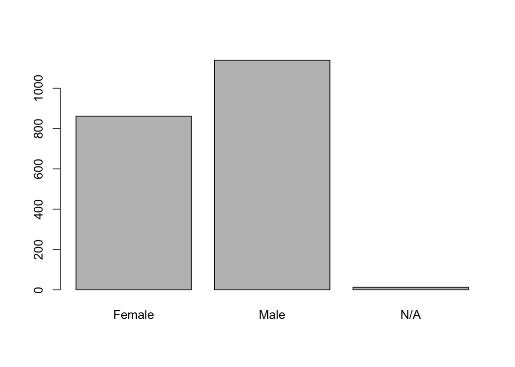

```r
barplot(table(data$Gender))
```

And if we want to make more beautiful plots, we can use `ggplot2` instead of base R:

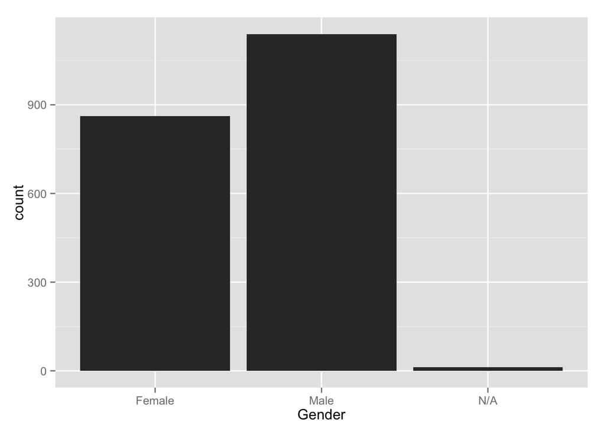

```r
library(ggplot2)
ggplot(data, aes(Gender)) + geom_histogram()
```

## More about plotting

I’m interested in seeing the distribution of different ALL subgroups within their study cohort. Also, lets save the table to a variable so we can work on it some more.

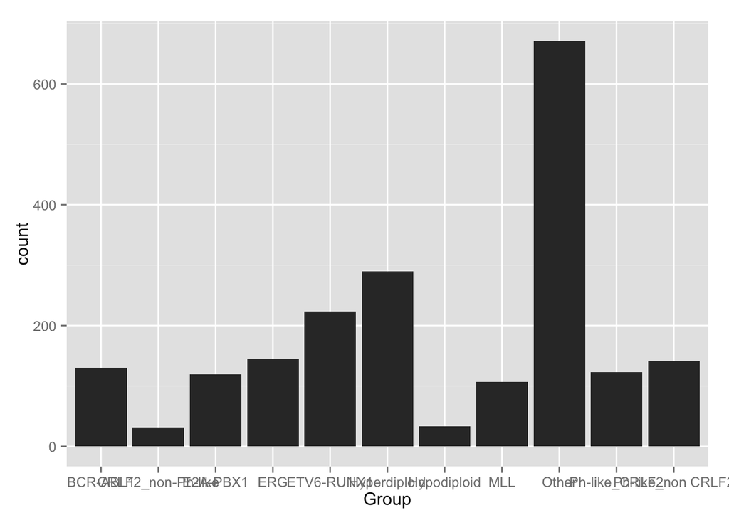

```r
plot <- ggplot(data, aes(Group)) + geom_bar()
print(plot)
```

The power of ggplot is that we can easily extend our plot, by adding layers.  
For example, its meaningful in ALL to view subgroup distribution by age group. We can easily do that by using `facet_wrap`

```r
levels(data$Age)
```

```
## [1] "Adolescent"   "Childhood HR" "Childhood SR" "Young adult"
```

```r
# Reorder the Age factors so that it goes from young to old, low to high risk
data$Age <- factor(data$Age, levels=c("Childhood SR", "Childhood HR", "Adolescent", "Young adult"))
levels(data$Age)
```

```
## [1] "Childhood SR" "Childhood HR" "Adolescent"   "Young adult"
```

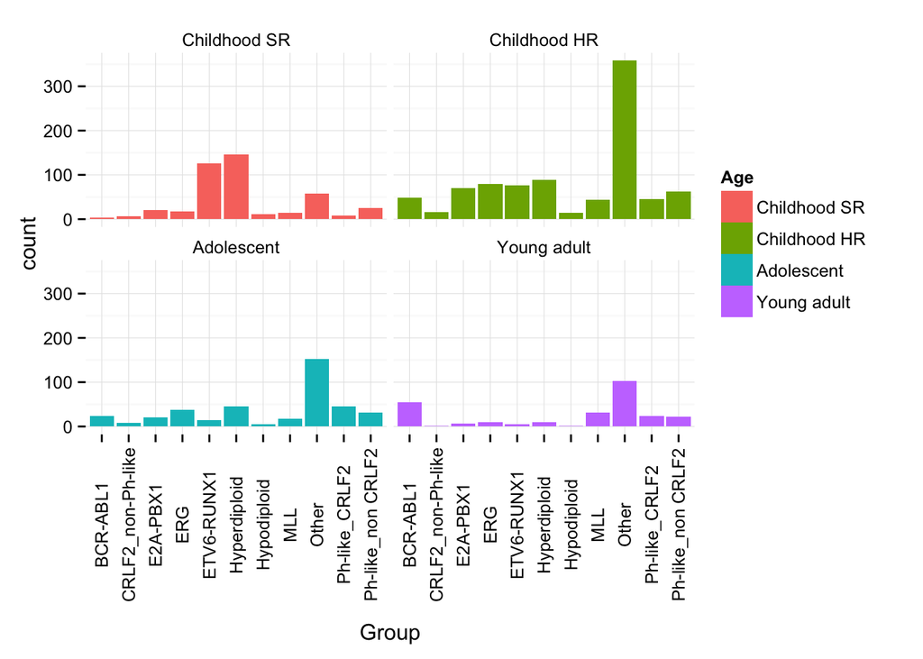

```r
plot <- ggplot(data, aes(Group, fill=Age)) + geom_bar()
plot <- plot + facet_wrap(~Age)
plot <- plot + theme_minimal()
plot <- plot + theme(axis.text.x = element_text(angle=90, vjust=0.5))
print(plot)
```

In some cases, R will not automatically understand the type of data in each variable. For example, here we need to tell it to treat white blood cell count (WBC) is an integer, not a factor.

Also, we continue extending the usage of `ggplot`.

```r
str(data$WBC)
```

```
##  Factor w/ 944 levels "0.4","0.5","0.6",..: 395 222 8 640 789 519 370 543 372 565 ...
```

```r
# Convert to integer
data$WBC <- as.integer(as.character(data$WBC))
# Now do summary of the variable
summary(data$WBC)
```

```
##    Min. 1st Qu.  Median    Mean 3rd Qu.    Max.    NA's
##     0.0     5.0    20.5    60.9    77.0  1310.0      67
```

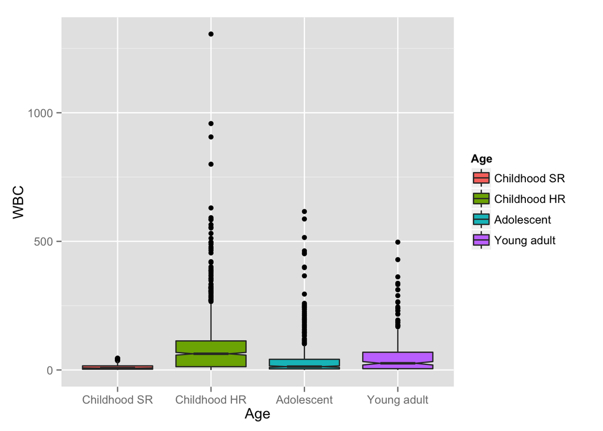

```r
# And make a boxplot: a warning message will alert you to the 67 records that did not have a WBC recorded and are dropped
plot <- ggplot(data, aes(Age, WBC, fill=Age))
plot + geom_boxplot(notch=TRUE)
```

Some cases have really high WBCs. Maybe we should log-transform our Y-axis to better represent our data.

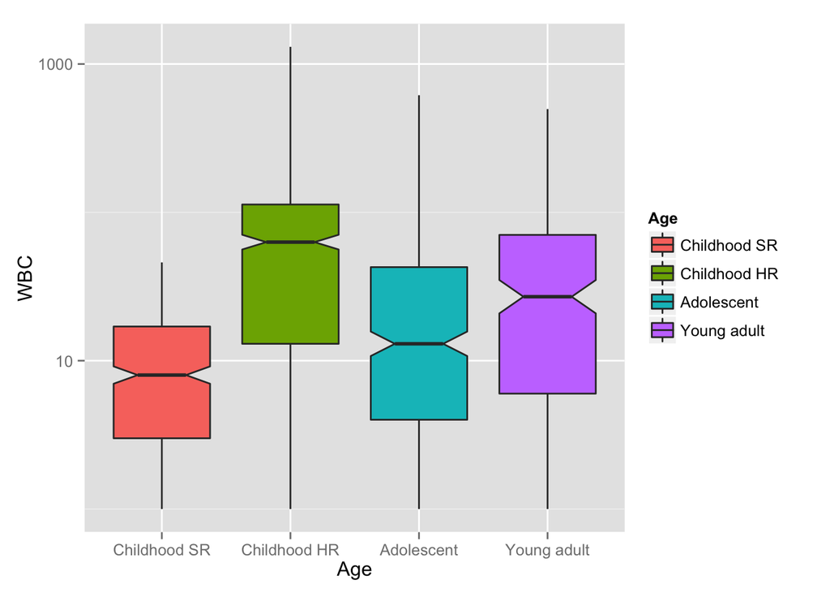

```r
plot + geom_boxplot(notch=TRUE) + scale_y_log10()
```

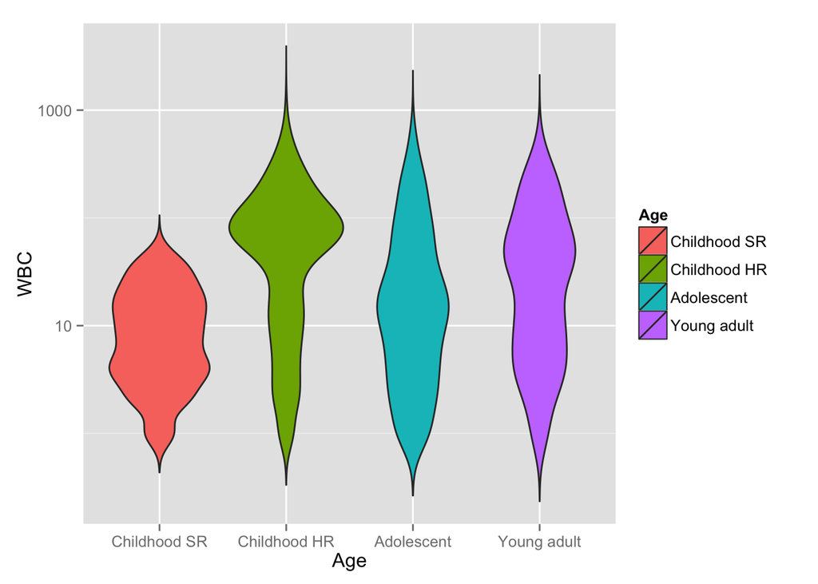

```r
plot + geom_violin(trim = FALSE) + scale_y_log10()
```

Other ways of visualizing the difference in WBC distribution across age groups

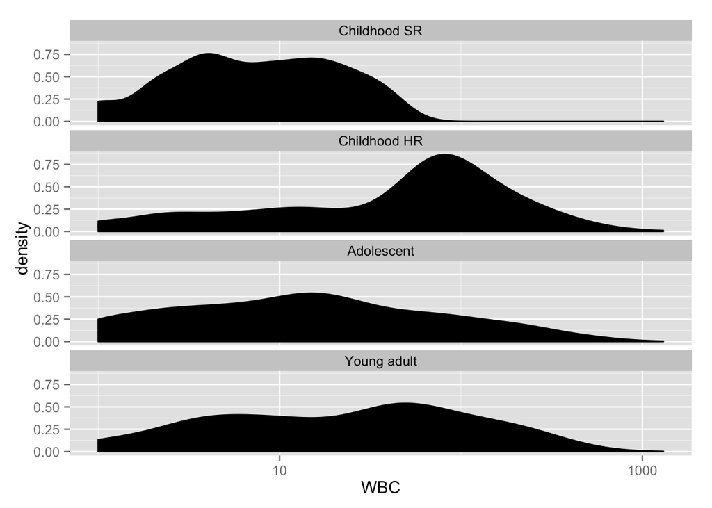

```r
plot <- ggplot(data, aes(WBC)) + geom_density(fill = "black") + scale_x_log10() + facet_wrap(~Age, ncol=1)
print(plot)
```

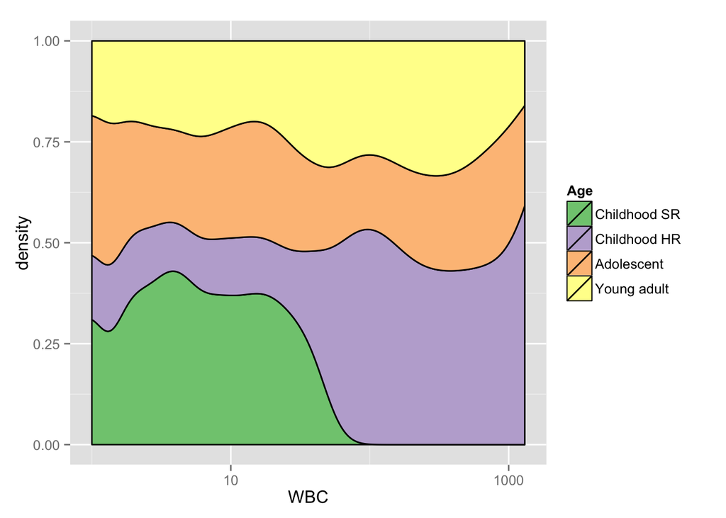

```r
plot2 <- ggplot(data, aes(WBC, fill=Age)) + geom_density(position="fill") + scale_x_log10() + scale_fill_brewer(type = "qual")
print(plot2)
```

If you’d rather show a pie chart, that is easy

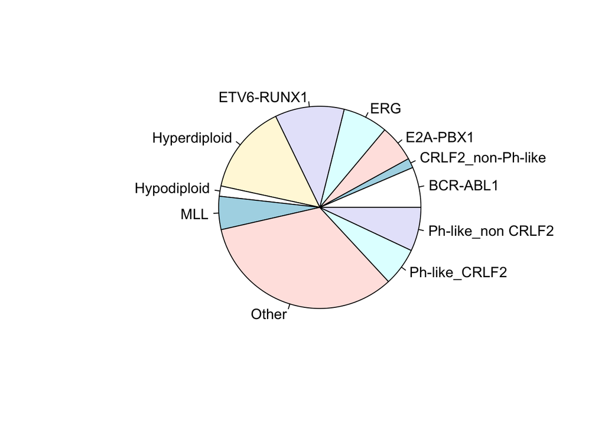

```r
pie(table(data$Group))
```